# Introduction to R: Objects, Data, and Environmental Analysis

Marc Los Huertos

EA030 · Compiled 2026-04-14

EA030 — Core R Skills — Module R00

# Introduction to R: Objects, Data & Environmental Analysis

**Prof. Marc Los Huertos** • Pomona College • EA030 Environmental Analysis

← Back to R Tricks

R as Calculator Objects Vectors Data Frames Summary Stats Graphics Linear Models Case Study

#### 🎯 Learning Outcomes

1. Use R as a calculator with arithmetic operators and mathematical functions.
2. Create and interrogate vectors — the fundamental R object.
3. Build data frames and access variables with the `$` operator.
4. Compute summary statistics on environmental data.
5. Produce informative base-R graphics with labeled axes.
6. Fit and interpret a simple linear model with `lm()`.
7. Apply these skills to a real lake temperature profile dataset.

> **What this module covers.** R is an open-source statistical computing environment used across environmental science, ecology, hydrology, and climate research. This module builds the foundation you need to work with data in R: understanding how R stores information as *objects*, how to combine objects into data frames, and how to explore and model environmental data. All data used here are self-contained — no files to download.

## 1. R as a Calculator

Before writing complex analyses, get comfortable using R interactively. R understands standard arithmetic directly at the console prompt (`>`).

### Arithmetic operators

| Operation | Operator | Example | Result |
| --- | --- | --- | --- |
| Addition | `+` | `6 + 5` | `11` |
| Subtraction | `-` | `6 - 5` | `1` |
| Multiplication | `*` | `6 * 5` | `30` |
| Division | `/` | `3 / 5` | `0.6` |
| Exponentiation | `^` | `3 ^ 2` | `9` |
| Integer division | `%/%` | `7 %/% 2` | `3` |
| Modulo (remainder) | `%%` | `7 %% 2` | `1` |

```r
# Basic arithmetic — type these in your console and observe the results
6 + 5
```

```
## [1] 11
```

```r
3 / 5
```

```
## [1] 0.6
```

```r
3 ^ 2
```

```
## [1] 9
```

### Mathematical functions

For more complex calculations, R provides built-in functions. All functions use parentheses; what goes inside is called the *argument*.

```r
log10(100)         # base-10 logarithm: how many pH units?
```

```
## [1] 2
```

```r
log(2.718282)      # natural log (base e)
```

```
## [1] 1
```

```r
sqrt(144)          # square root
```

```
## [1] 12
```

```r
abs(-7.3)          # absolute value — useful for anomalies
```

```
## [1] 7.3
```

```r
round(3.14159, 2)  # round to 2 decimal places
```

```
## [1] 3.14
```

**💡 No news is good news** When R executes your command without printing an error, it worked. Silence means success. When something does go wrong, R prints a message starting with `Error` or `Warning`. Read those messages carefully — they usually tell you exactly what went wrong.

### Environmental example: the Michaelis-Menten equation

Many ecological processes follow the Michaelis-Menten form — nutrient uptake by phytoplankton, enzyme kinetics, oxygen consumption. The equation is:

$$V = V_{max} \frac{S}{K_s +
S}$$

where $V$ is the uptake rate, $V_{max}$ is the maximum rate, $S$ is substrate concentration, and $K_s$ is the half-saturation constant. With $V_{max} = 0.18$, $S = 0.5$, and $K_s = 0.3$:

```r
Vmax <- 0.18
S    <- 0.5
Ks   <- 0.3
V    <- Vmax * (S / (Ks + S))
V   # print the result
```

```
## [1] 0.1125
```

Notice how assigning values to named objects (`<-`) makes the formula readable and easy to modify. Change $S$ from 0.5 to 1.5 and re-run — does the uptake rate saturate as expected?

**📌 Try it: explore operator precedence** Type

```
2
+ 3 * 4
```

and then `(2 + 3) * 4`. R follows standard mathematical order of operations. When in doubt, use parentheses to make your intent explicit.

## 2. Objects in R

The single most important concept in R is the **object**. Everything in R — a number, a list of measurements, a statistical model, a plot — is an object with a name you assign. You create objects with the assignment operator `<-`.

```r
# Create a scalar object (length-1 vector)
air_temp <- 18.5     # degrees Celsius, a single measurement

# Print it by typing its name
air_temp
```

```
## [1] 18.5
```

Object names are case-sensitive: `air_temp`, `Air_Temp`, and `AIR_TEMP` are three different objects. R convention uses `snake_case` (lowercase words separated by underscores). Start names with a letter, never a digit.

### Common R object types

Vector

c(), seq(), rep()

An ordered sequence of values of a single type. The most fundamental R object.

Data Frame

data.frame(), read.csv()

A table: columns are equal-length vectors (like a spreadsheet). The workhorse of data analysis.

Matrix

matrix(), as.matrix()

A 2-D array of values, all the same type. Used in multivariate analyses.

List

list()

An ordered collection that can hold objects of different types and lengths — including other lists.

Factor

factor(), as.factor()

A categorical variable with fixed levels. Tells R to treat values as groups, not numbers.

Linear Model

lm(), aov()

The output of a model fit — an object containing coefficients, residuals, fit statistics, and more.

Don’t try to memorize all of these now. As you work through this module you will create each type naturally.

## 3. Vectors: R’s Core Data Structure

A **vector** stores an ordered sequence of values of a single type (numeric, character, or logical). Use `c()` — short for *concatenate* — to create one.

### Creating numeric vectors

```r
# A vector of water temperatures measured at a field site (°C)
temperature <- c(22.1, 21.8, 20.5, 18.2, 14.3, 11.0, 10.2, 9.8)

# A corresponding vector of depths (m)
depth <- c(0, 1, 2, 3, 4, 5, 6, 7)

# Print them
temperature
```

```
## [1] 22.1 21.8 20.5 18.2 14.3 11.0 10.2  9.8
```

```r
depth
```

```
## [1] 0 1 2 3 4 5 6 7
```

### Interrogating vectors

Once you have a vector, a set of built-in functions let you explore it:

```r
length(temperature)  # how many observations?
```

```
## [1] 8
```

```r
sum(temperature)     # total sum
```

```
## [1] 127.9
```

```r
mean(temperature)    # arithmetic mean
```

```
## [1] 15.9875
```

```r
min(temperature)     # minimum value
```

```
## [1] 9.8
```

```r
max(temperature)     # maximum value
```

```
## [1] 22.1
```

```r
range(temperature)   # min and max together
```

```
## [1]  9.8 22.1
```

```r
sd(temperature)      # standard deviation
```

```
## [1] 5.290271
```

### Sequences and repetition

Typing out every value by hand gets tedious. Use `seq()` and `rep()` for structured sequences:

```r
# Depths from 0 to 14 m in 2-m increments
depth_2m <- seq(from = 0, to = 14, by = 2)
depth_2m
```

```
## [1]  0  2  4  6  8 10 12 14
```

```r
# Replicate a treatment label 5 times each
treatment <- c(rep("Control", 5), rep("Heated", 5), rep("Ambient", 5))
treatment
```

```
##  [1] "Control" "Control" "Control" "Control" "Control" "Heated"  "Heated"
##  [8] "Heated"  "Heated"  "Heated"  "Ambient" "Ambient" "Ambient" "Ambient"
## [15] "Ambient"
```

### Character and logical vectors

Vectors don’t have to contain numbers. Environmental data often include site names, species identifiers, or quality-control flags:

```r
# Character vector of sampling sites
sites <- c("Kern River", "Mojave Basin", "Santa Ana", "LA River")

# Logical vector: is the site impaired?
impaired <- c(FALSE, TRUE, TRUE, TRUE)

# Check type
class(sites)
```

```
## [1] "character"
```

```r
class(impaired)
```

```
## [1] "logical"
```

**⚠️ Vectors must be a single type** If you mix numbers and characters in `c()`, R silently converts everything to character — a process called *coercion*. Try

```
c(1, 2,
“three”)
```

and check its class. This is a common source of confusion when reading messy data files.

### Indexing: selecting elements

Use square brackets `[ ]` to extract elements by position (index starts at 1, not 0):

```r
temperature[1]        # first element (surface temperature)
```

```
## [1] 22.1
```

```r
temperature[6]        # sixth element
```

```
## [1] 11
```

```r
temperature[1:3]      # elements 1 through 3
```

```
## [1] 22.1 21.8 20.5
```

```r
temperature[c(1, 4, 8)]  # specific positions
```

```
## [1] 22.1 18.2  9.8
```

You can also use a logical condition to filter:

```r
# Which depths have temperatures below 12°C? (hypolimnion)
depth[temperature < 12]
```

```
## [1] 5 6 7
```

```r
# The actual temperatures in the hypolimnion
temperature[temperature < 12]
```

```
## [1] 11.0 10.2  9.8
```

**📝 Try it: vector arithmetic** Vectors support element-wise arithmetic. Convert temperature from Celsius to Fahrenheit: `temperature * 9/5 + 32`. Create a new object called `temp_f` and print it. Notice R applies the conversion to every element at once — no loop needed.

## 4. Data Frames: Tabular Environmental Data

A **data frame** is a collection of equal-length vectors arranged as columns — exactly like a spreadsheet, but with R’s statistical power behind it. Each column is a variable; each row is an observation.

### Building a data frame from vectors

```r
# pHake Lake: a simulated alpine lake used in EA030 labs
# Data represent a summer thermal stratification profile

phake_depth <- c(0, 0.5, 1, 2, 3, 4, 5, 6, 7, 8, 9, 10, 12, 14)
phake_temp  <- c(22.4, 22.1, 21.8, 20.9, 19.1, 16.5,
                 13.2, 11.4, 10.8, 10.4, 10.1, 10.0, 9.9, 9.8)

# Confirm vectors are the same length before combining
length(phake_depth) == length(phake_temp)
```

```
## [1] TRUE
```

```r
# Build the data frame
phake <- data.frame(
  depth_m     = phake_depth,
  temp_c      = phake_temp
)
```

### Inspecting a data frame

```r
# Preview the top six rows
head(phake)
```

```
##   depth_m temp_c
## 1     0.0   22.4
## 2     0.5   22.1
## 3     1.0   21.8
## 4     2.0   20.9
## 5     3.0   19.1
## 6     4.0   16.5
```

```r
# Structure: types, dimensions, a few values
str(phake)
```

```
## 'data.frame':    14 obs. of  2 variables:
##  $ depth_m: num  0 0.5 1 2 3 4 5 6 7 8 ...
##  $ temp_c : num  22.4 22.1 21.8 20.9 19.1 16.5 13.2 11.4 10.8 10.4 ...
```

```r
# Quick summary statistics for every column
summary(phake)
```

```
##     depth_m           temp_c
##  Min.   : 0.000   Min.   : 9.80
##  1st Qu.: 2.250   1st Qu.:10.18
##  Median : 5.500   Median :12.30
##  Mean   : 5.821   Mean   :14.89
##  3rd Qu.: 8.750   3rd Qu.:20.45
##  Max.   :14.000   Max.   :22.40
```

### Accessing columns with `$`

The `$` operator drills into a data frame column and returns it as a vector:

```r
phake$depth_m        # depth column as a vector
```

```
##  [1]  0.0  0.5  1.0  2.0  3.0  4.0  5.0  6.0  7.0  8.0  9.0 10.0 12.0 14.0
```

```r
mean(phake$temp_c)   # mean temperature across all depths
```

```
## [1] 14.88571
```

**📚 The data frame as the unit of analysis** Keeping all your variables together in a single data frame — rather than as separate loose vectors — is good practice. It prevents length mismatches, makes your code readable, and is required by most modelling and plotting functions that use the `data =` argument.

### Adding a derived column

We can add new variables directly to the data frame:

```r
# Convert temperature to Fahrenheit and add as a new column
phake$temp_f <- phake$temp_c * 9 / 5 + 32

# A depth class column: epilimnion vs. hypolimnion
phake$layer <- ifelse(phake$temp_c > 15, "Epilimnion", "Hypolimnion")

head(phake)
```

```
##   depth_m temp_c temp_f      layer
## 1     0.0   22.4  72.32 Epilimnion
## 2     0.5   22.1  71.78 Epilimnion
## 3     1.0   21.8  71.24 Epilimnion
## 4     2.0   20.9  69.62 Epilimnion
## 5     3.0   19.1  66.38 Epilimnion
## 6     4.0   16.5  61.70 Epilimnion
```

## 5. Exploring Data: Summary Statistics

Before fitting any model, always explore your data. Summary statistics reveal the central tendency, spread, and shape of your variables.

### Descriptive statistics

```r
# Central tendency
mean(phake$temp_c)
```

```
## [1] 14.88571
```

```r
median(phake$temp_c)
```

```
## [1] 12.3
```

```r
# Spread
sd(phake$temp_c)          # standard deviation
```

```
## [1] 5.278091
```

```r
var(phake$temp_c)         # variance
```

```
## [1] 27.85824
```

```r
range(phake$temp_c)       # min and max
```

```
## [1]  9.8 22.4
```

```r
IQR(phake$temp_c)         # interquartile range
```

```
## [1] 10.275
```

```r
# The all-in-one function
summary(phake$temp_c)
```

```
##    Min. 1st Qu.  Median    Mean 3rd Qu.    Max.
##    9.80   10.18   12.30   14.89   20.45   22.40
```

### Stratified summaries with `tapply()`

The `tapply()` function computes a statistic on a variable *within* groups — here the epilimnion versus hypolimnion layers we defined above:

```r
tapply(phake$temp_c, phake$layer, mean)
```

```
##  Epilimnion Hypolimnion
##    20.46667    10.70000
```

```r
tapply(phake$temp_c, phake$layer, sd)
```

```
##  Epilimnion Hypolimnion
##    2.279181    1.142679
```

**📌 Check your data before you model it** Always run `summary()` and look at your data frame with `head()` and `str()` before doing any analysis. Watch for: impossible values (temperature of −99 is usually a missing data code), unexpected `NA` values, and variables stored as the wrong type (numbers stored as characters).

## 6. Basic Graphics

R’s base graphics system produces publication-ready figures directly from data frames and vectors. The key function is `plot()`.

### A simple scatter plot

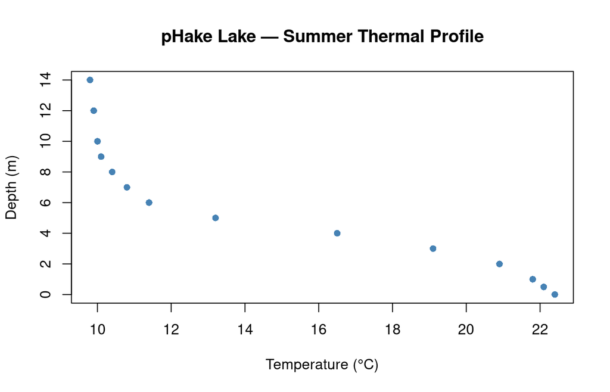

```r
plot(phake$temp_c, phake$depth_m,
     xlab = "Temperature (°C)",
     ylab = "Depth (m)",
     main = "pHake Lake — Summer Thermal Profile",
     pch  = 16,        # solid circle symbols
     col  = "steelblue")
```

### Inverting the y-axis for depth profiles

Limnologists and oceanographers always plot depth increasing *downward* on the y-axis, matching the physical orientation of the water column. Reversing the y-axis requires passing a reversed `ylim`:

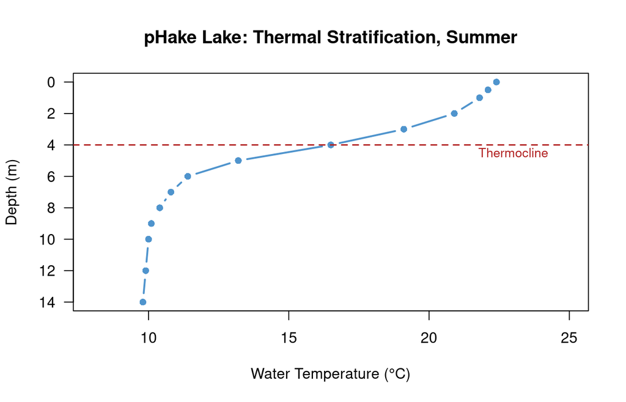

```r
# Classic depth profile: depth on y (inverted), temperature on x
plot(x    = phake$temp_c,
     y    = phake$depth_m,
     xlim = c(8, 25),
     ylim = rev(range(phake$depth_m)),  # reverse: deeper = lower
     xlab = "Water Temperature (°C)",
     ylab = "Depth (m)",
     main = "pHake Lake: Thermal Stratification, Summer",
     type = "b",      # "b" = both points and lines
     pch  = 16,
     col  = "steelblue3",
     lwd  = 2,
     las  = 1)         # horizontal axis labels

# Add a horizontal line marking the thermocline
abline(h = 4, lty = 2, col = "firebrick", lwd = 1.5)
text(x = 23, y = 4.5, labels = "Thermocline", col = "firebrick", cex = 0.85)
```

### Key graphical parameters

| Parameter | Meaning | Example values |
| --- | --- | --- |
| `xlab`, `ylab` | Axis labels | `"Temperature (°C)"` |
| `main` | Plot title | use sparingly — use figure captions instead |
| `pch` | Point symbol | `16` = filled circle, `17` = triangle, `1` = open circle |
| `col` | Color | `"steelblue"`, `"#2d5a3d"`, `rgb(0.2, 0.4, 0.3)` |
| `lwd` | Line width | `1` (default), `2`, `3` |
| `lty` | Line type | `1` = solid, `2` = dashed, `3` = dotted |
| `cex` | Character expansion (size) | `1` (default), `1.5` = 50% larger |
| `las` | Axis label orientation | `1` = horizontal (recommended) |
| `type` | Plot type | `"p"` = points, `"l"` = lines, `"b"` = both |

**📈 Science figures vs. Excel defaults** Excel defaults are designed for business presentations, not scientific communication. In scientific figures: omit the box frame (`bty = “n”`), always label axes with units, avoid decorative colors, and let a figure caption — not a title — describe what the reader should take away. R makes it easy to adopt these conventions.

### Histograms and boxplots

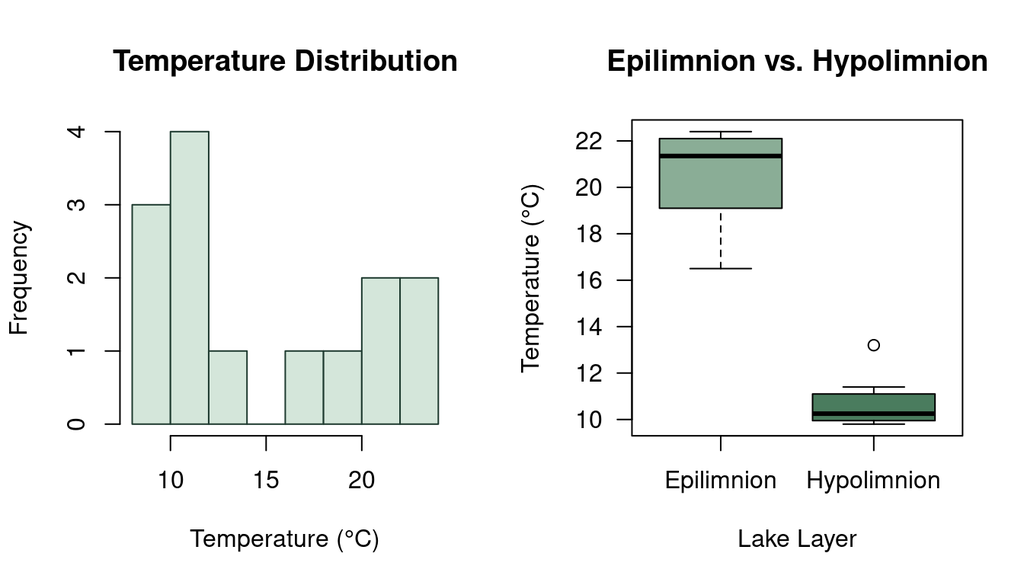

```r
par(mfrow = c(1, 2))  # two panels side by side

hist(phake$temp_c,
     breaks = 8,
     col    = "#d4e6da",
     border = "#1e3a2f",
     xlab   = "Temperature (°C)",
     main   = "Temperature Distribution")

boxplot(temp_c ~ layer, data = phake,
        col    = c("#8aad96", "#4a7c5e"),
        ylab   = "Temperature (°C)",
        xlab   = "Lake Layer",
        las    = 1,
        main   = "Epilimnion vs. Hypolimnion")
```

```r
par(mfrow = c(1, 1))  # reset to single panel
```

## 7. Linear Models in R

The linear model is the cornerstone of quantitative analysis in environmental science. Whether you are testing for a treatment effect (ANOVA) or estimating a continuous relationship (regression), the underlying framework is the same:

$$y \sim \alpha + \beta \cdot x +
\varepsilon$$

$\alpha$ is the intercept, $\beta$ is the slope, and $\varepsilon$ is the residual error. In R, `~` means “is modelled as a function of.”

### Fitting a model with `lm()`

Temperature decreases with depth in a stratified lake. We can estimate this relationship formally:

```r
# Fit temperature as a function of depth
temp_model <- lm(temp_c ~ depth_m, data = phake)

# Inspect the coefficients
coef(temp_model)
```

```
## (Intercept)     depth_m
##   21.271919   -1.097017
```

The intercept is the estimated surface temperature (depth = 0); the slope is the average change in temperature per additional metre of depth.

### Reading the model summary

```r
summary(temp_model)
```

```
##
## Call:
## lm(formula = temp_c ~ depth_m, data = phake)
##
## Residuals:
##     Min      1Q  Median      3Q     Max
## -3.2898 -1.8965  0.4087  1.5630  3.8863
##
## Coefficients:
##             Estimate Std. Error t value Pr(>|t|)
## (Intercept)  21.2719     1.0190  20.875 8.46e-11 ***
## depth_m      -1.0970     0.1416  -7.748 5.21e-06 ***
## ---
## Signif. codes:  0 '***' 0.001 '**' 0.01 '*' 0.05 '.' 0.1 ' ' 1
##
## Residual standard error: 2.242 on 12 degrees of freedom
## Multiple R-squared:  0.8334, Adjusted R-squared:  0.8195
## F-statistic: 60.04 on 1 and 12 DF,  p-value: 5.207e-06
```

Key values to read:

- **Estimate (Intercept)**: predicted temperature at the surface.
- **Estimate (depth_m)**: for each additional metre of depth, temperature changes by this amount.
- **Pr(>|t|)**: p-value for whether each coefficient is significantly different from zero.
- **Multiple R-squared**: proportion of variance in temperature explained by depth. 1.0 = perfect fit; 0 = no linear relationship.
- **F-statistic / p-value**: is the overall model significantly better than no predictor at all?

**⚠️ Does a straight line make sense here?** Lake temperature vs. depth is *not* actually linear — there is an abrupt thermocline. A linear model here simplifies reality. Always plot your data and inspect residuals before trusting a model summary. The R² being high does not mean the model is appropriate.

### Plotting the fitted line

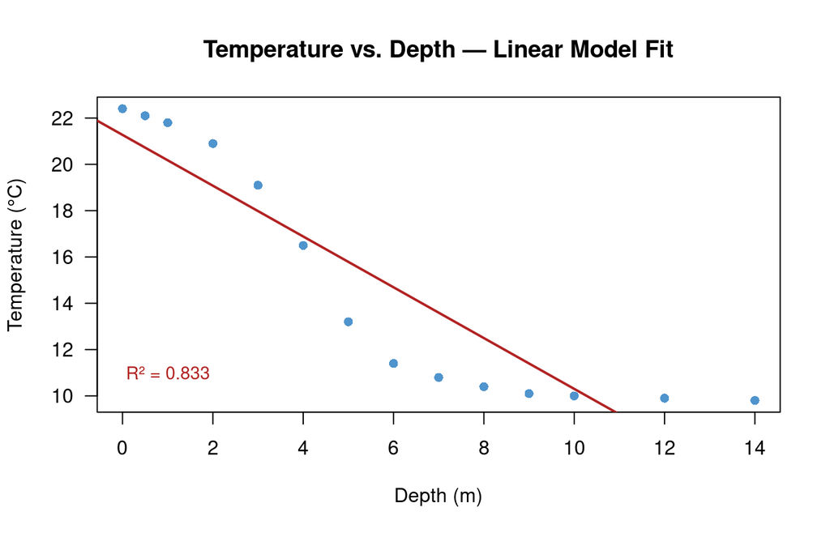

```r
plot(x    = phake$depth_m,
     y    = phake$temp_c,
     xlab = "Depth (m)",
     ylab = "Temperature (°C)",
     main = "Temperature vs. Depth — Linear Model Fit",
     pch  = 16, col = "steelblue3", las = 1)

abline(temp_model, col = "firebrick", lwd = 2)

# Add the R² value as a text annotation
r2 <- round(summary(temp_model)$r.squared, 3)
text(x = 1, y = 11,
     labels = paste0("R² = ", r2),
     col = "firebrick", cex = 0.9)
```

### Extracting specific model outputs

```r
# Coefficients
coef(temp_model)["(Intercept)"]
```

```
## (Intercept)
##    21.27192
```

```r
coef(temp_model)["depth_m"]
```

```
##   depth_m
## -1.097017
```

```r
# Fitted values (predicted temperatures at each observed depth)
head(fitted(temp_model))
```

```
##        1        2        3        4        5        6
## 21.27192 20.72341 20.17490 19.07789 17.98087 16.88385
```

```r
# Residuals (observed minus fitted)
head(residuals(temp_model))
```

```
##          1          2          3          4          5          6
##  1.1280812  1.3765895  1.6250979  1.8221146  1.1191314 -0.3838519
```

```r
# Confidence intervals for the coefficients
confint(temp_model)
```

```
##                 2.5 %     97.5 %
## (Intercept) 19.051657 23.4921804
## depth_m     -1.405495 -0.7885387
```

**📌 Getting help** To see what arguments a function accepts, type `?lm` or `help(lm)` in the console. The **Examples** section at the bottom of any help page is the fastest way to learn — paste it in and run it, then adapt it to your data.

## 8. Case Study: pHake Lake Temperature Profile

pHake Lake is a simulated alpine lake used in EA030 field laboratories. In this case study we work through a complete analysis workflow — from raw data to interpreted figure — using the seasonal temperature profile collected by a data logger.

### The dataset

The data below represent temperature readings taken at standard depth intervals during summer stratification. All data are embedded directly in this document — no external file needed.

```r
# Full summer dataset — three replicate casts averaged
phake_full <- data.frame(
  depth_m  = c(0.0, 0.5, 1.0, 1.5, 2.0, 2.5, 3.0, 3.5,
               4.0, 4.5, 5.0, 5.5, 6.0, 7.0, 8.0, 9.0,
               10.0, 11.0, 12.0, 13.0, 14.0),
  temp_c   = c(22.4, 22.2, 22.0, 21.7, 21.2, 20.3, 19.0, 17.4,
               15.3, 13.1, 11.5, 10.9, 10.6, 10.3, 10.1, 10.05,
               10.0, 9.98, 9.95, 9.92, 9.90),
  do_mgl   = c(9.1, 9.0, 9.0, 8.9, 8.8, 8.5, 8.2, 7.8,
               7.1, 6.5, 5.9, 5.2, 4.8, 4.5, 4.3, 4.2,
               4.1, 4.1, 4.0, 4.0, 3.9)   # dissolved oxygen (mg/L)
)

str(phake_full)
```

```
## 'data.frame':    21 obs. of  3 variables:
##  $ depth_m: num  0 0.5 1 1.5 2 2.5 3 3.5 4 4.5 ...
##  $ temp_c : num  22.4 22.2 22 21.7 21.2 20.3 19 17.4 15.3 13.1 ...
##  $ do_mgl : num  9.1 9 9 8.9 8.8 8.5 8.2 7.8 7.1 6.5 ...
```

```r
summary(phake_full)
```

```
##     depth_m           temp_c          do_mgl
##  Min.   : 0.000   Min.   : 9.90   Min.   :3.900
##  1st Qu.: 2.500   1st Qu.:10.05   1st Qu.:4.200
##  Median : 5.000   Median :11.50   Median :5.900
##  Mean   : 5.857   Mean   :14.66   Mean   :6.281
##  3rd Qu.: 9.000   3rd Qu.:20.30   3rd Qu.:8.500
##  Max.   :14.000   Max.   :22.40   Max.   :9.100
```

### Identifying the thermocline

The thermocline is the depth zone of maximum temperature change — where the water column transitions from warm, well-mixed epilimnion to cold, stable hypolimnion. We can find it by computing the temperature gradient (change per metre):

```r
# Calculate temperature gradient between consecutive depths
delta_temp  <- diff(phake_full$temp_c)   # differences between adjacent rows
delta_depth <- diff(phake_full$depth_m)
gradient    <- delta_temp / delta_depth  # °C per metre

# Depth of maximum gradient (most negative = steepest cooling)
thermo_depth <- phake_full$depth_m[which.min(gradient)]
cat("Thermocline centre depth:", thermo_depth, "m\n")
```

```
## Thermocline centre depth: 4 m
```

```r
cat("Maximum gradient:", round(min(gradient), 2), "°C/m\n")
```

```
## Maximum gradient: -4.4 °C/m
```

### Publication-quality depth profile

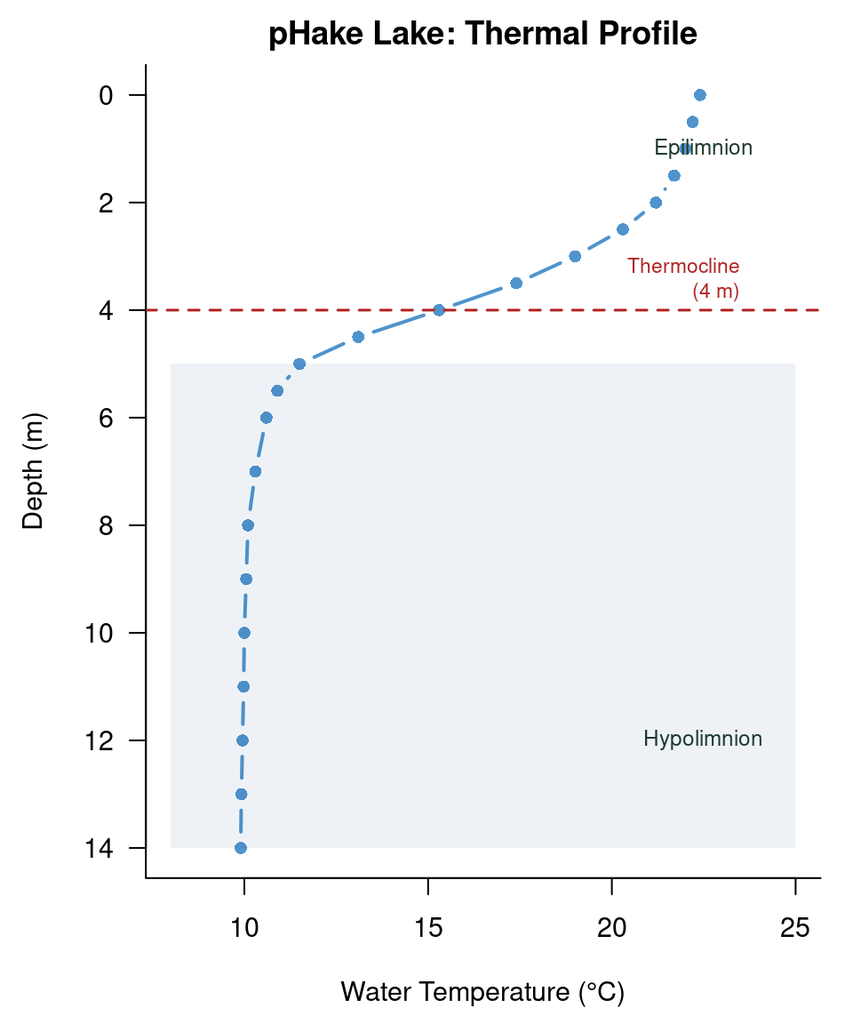

```r
par(mar = c(4.5, 4.5, 2, 1), las = 1, cex = 0.95)

plot(x    = phake_full$temp_c,
     y    = phake_full$depth_m,
     xlim = c(8, 25),
     ylim = rev(range(phake_full$depth_m)),
     xlab = "Water Temperature (°C)",
     ylab = "Depth (m)",
     main = "pHake Lake: Thermal Profile",
     type = "b",
     pch  = 16,
     col  = "steelblue3",
     lwd  = 2,
     bty  = "l")   # only left and bottom axes

# Shade epilimnion vs. hypolimnion
rect(xleft = 8, xright = 25,
     ybottom = thermo_depth + 1, ytop = 14,
     col = rgb(0.18, 0.36, 0.56, 0.08), border = NA)

# Mark thermocline
abline(h = thermo_depth, lty = 2, col = "firebrick", lwd = 1.5)
text(x = 23.5, y = thermo_depth - 0.6,
     labels = paste0("Thermocline\n(", thermo_depth, " m)"),
     col = "firebrick", cex = 0.75, adj = 1)

# Add layer labels
text(x = 22.5, y = 1,   labels = "Epilimnion",  cex = 0.8, col = "#1e3a2f")
text(x = 22.5, y = 12,  labels = "Hypolimnion", cex = 0.8, col = "#1e3a2f")
```

### Dual-variable profile: temperature and dissolved oxygen

Dissolved oxygen (DO) often mirrors temperature in stratified lakes — warm surface waters lose oxygen at depth. Plotting both on the same figure requires a second axis:

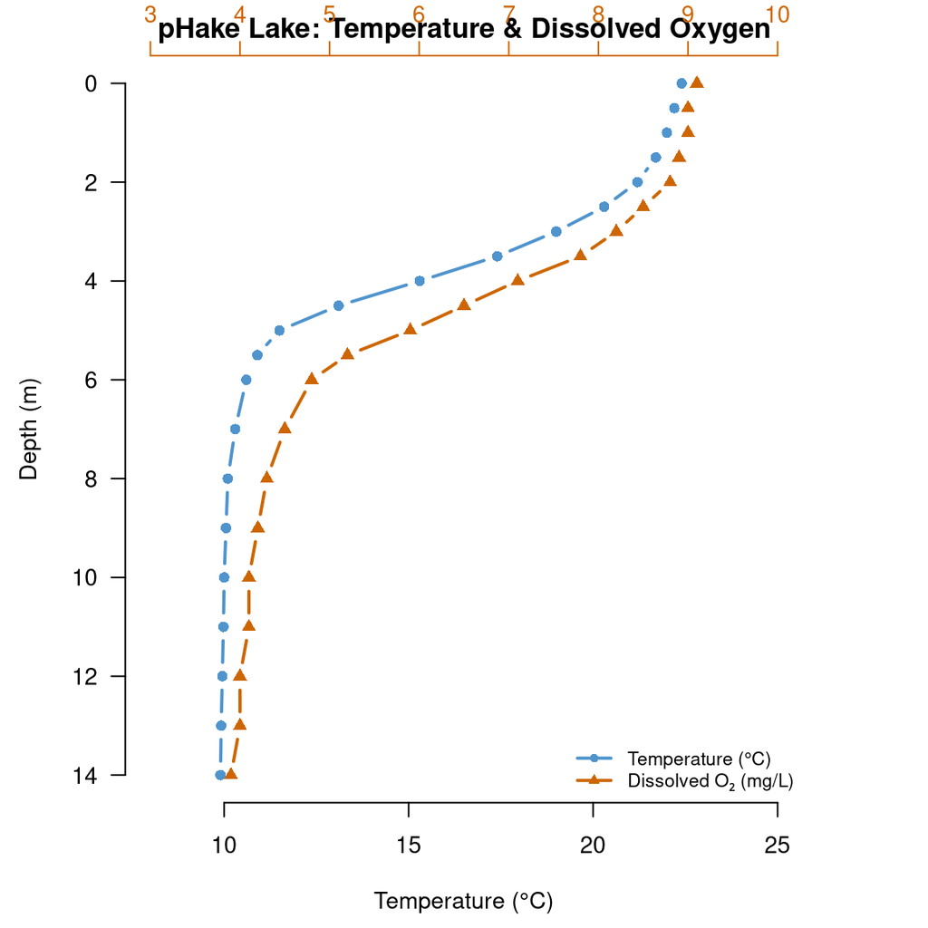

```r
par(mar = c(4.5, 4.5, 2, 4.5), las = 1, cex = 0.9)

# --- Temperature (primary x-axis, bottom) ---
plot(x    = phake_full$temp_c,
     y    = phake_full$depth_m,
     xlim = c(8, 25),
     ylim = rev(range(phake_full$depth_m)),
     xlab = "Temperature (°C)",
     ylab = "Depth (m)",
     main = "pHake Lake: Temperature & Dissolved Oxygen",
     type = "b", pch = 16, col = "steelblue3", lwd = 2, bty = "n")

# --- Dissolved oxygen (secondary x-axis, top) ---
par(new = TRUE)
plot(x    = phake_full$do_mgl,
     y    = phake_full$depth_m,
     xlim = c(3, 10),
     ylim = rev(range(phake_full$depth_m)),
     xlab = "", ylab = "", axes = FALSE,
     type = "b", pch = 17, col = "darkorange3", lwd = 2)

axis(side = 3, col = "darkorange3", col.axis = "darkorange3")
mtext("Dissolved Oxygen (mg/L)", side = 3, line = 2.5, col = "darkorange3", cex = 0.85)

legend("bottomright",
       legend = c("Temperature (°C)", "Dissolved O₂ (mg/L)"),
       col    = c("steelblue3", "darkorange3"),
       lty    = 1, pch = c(16, 17), lwd = 2,
       bty    = "n", cex = 0.8)
```

### Fitting a segmented model concept

A simple linear model misses the non-linearity of thermal stratification. Below we compare R² for depth zones to illustrate how the relationship differs across layers:

```r
epi  <- phake_full[phake_full$depth_m <= thermo_depth, ]
hypo <- phake_full[phake_full$depth_m >  thermo_depth, ]

# Epilimnion model
lm_epi  <- lm(temp_c ~ depth_m, data = epi)
# Hypolimnion model
lm_hypo <- lm(temp_c ~ depth_m, data = hypo)

cat("Epilimnion slope:  ", round(coef(lm_epi)["depth_m"],  3), "°C/m\n")
```

```
## Epilimnion slope:   -1.673 °C/m
```

```r
cat("Hypolimnion slope: ", round(coef(lm_hypo)["depth_m"], 3), "°C/m\n")
```

```
## Hypolimnion slope:  -0.214 °C/m
```

```r
cat("Epilimnion R²:  ", round(summary(lm_epi)$r.squared,  3), "\n")
```

```
## Epilimnion R²:   0.864
```

```r
cat("Hypolimnion R²: ", round(summary(lm_hypo)$r.squared, 3), "\n")
```

```
## Hypolimnion R²:  0.545
```

The steeply negative slope in the epilimnion captures the thermocline gradient; the near-zero slope below confirms the isothermal hypolimnion.

#### 🔑 Introduction to R — Key Takeaways

- **Everything in R is an object.** Use `<-` to assign names. Objects persist in your Environment until you remove or overwrite them.
- **Vectors are the atom.** All other structures are built from them. Create with `c()`, index with `[ ]`, filter with logical conditions.
- **Data frames keep related vectors together.** Always use the `data =` argument in `plot()` and `lm()` — it makes code readable and avoids length errors.
- **No news is good news.** A silent return means success. Read error messages carefully — they usually identify the line and cause.
- **Explore before you model.** Run `summary()`, `str()`, and `head()` on every new dataset before fitting anything.
- **The linear model formula is `y ~ x`.** The tilde means “is modelled as a function of.” The `lm()` output object holds coefficients, residuals, R², and everything else.
- **Plot axis labels must include units.**

  ```
  xlab =
  “Temperature (°C)”
  ```

  — never leave axes unlabeled in scientific figures.
- **Invert the y-axis for depth profiles** with

  ```
  ylim =
  rev(range(depth))
  ```

  so deeper = lower on the page.

### What’s next?

- **RMarkdown & knitr** — weaving code, output, and prose into reproducible documents
- **Data Import** — reading CSV, Excel, and field data files into R
- **Visualization** — `ggplot2` for layered, publication-quality figures